# 1 Introduction

# 3 Data Exploration

## 3.1 Electricity Demand

```r
# Converts string DATETIME into dttm and creates timestamp columns
wrangle_demand_data <- function(df) {
  if ("DATETIME" %in% names(df)) {
    df <- df %>%
      mutate(DATETIME = dmy_hm(`DATETIME`, tz='AUstralia/Brisbane'), # Converst DATETIME to dttm
                          Year = year(DATETIME),        # Extract year
                          Month = month(DATETIME),      # Extract month
                          Day = day(DATETIME),          # Extract day
                          Hour = hour(DATETIME),        # Extract hour
                          Minute = minute(DATETIME)) %>%  # Extract minute
      mutate(TimeOfDay = Hour + Minute / 60,   # Time of the day (0 - 24)
             WeekOfMonth = factor(week(DATETIME) - week(floor_date(DATETIME, "month")) + 1, levels = c(1,2,3,4,5,6)),
             DayOfWeek = factor(wday(DATETIME, label=TRUE), levels = c("Sun", "Mon", "Tue", "Wed", "Thu", "Fri", "Sat")))
  } else {
    warning("DATETIME column not found in the dataframe.")
  }
  return(df)
}
```

```r
summary(data_demand_nsw)
```

```
##    DATETIME          TOTALDEMAND      REGIONID
##  Length:196513      Min.   : 5075   Length:196513
##  Class :character   1st Qu.: 7150   Class :character
##  Mode  :character   Median : 8053   Mode  :character
##                     Mean   : 8113
##                     3rd Qu.: 8959
##                     Max.   :14580
```

```r
df_demand_nsw <- wrangle_demand_data(data_demand_nsw)
head(df_demand_nsw)
```

```
## # A tibble: 6 × 11
##   DATETIME            TOTALDEMAND REGIONID  Year Month   Day  Hour Minute
##   <dttm>                    <dbl> <chr>    <dbl> <dbl> <int> <int>  <int>
## 1 2010-01-01 00:00:00       8038  NSW1      2010     1     1     0      0
## 2 2010-01-01 00:30:00       7809. NSW1      2010     1     1     0     30
## 3 2010-01-01 01:00:00       7484. NSW1      2010     1     1     1      0
## 4 2010-01-01 01:30:00       7117. NSW1      2010     1     1     1     30
## 5 2010-01-01 02:00:00       6812. NSW1      2010     1     1     2      0
## 6 2010-01-01 02:30:00       6544. NSW1      2010     1     1     2     30
## # ℹ 3 more variables: TimeOfDay <dbl>, WeekOfMonth <fct>, DayOfWeek <ord>
```

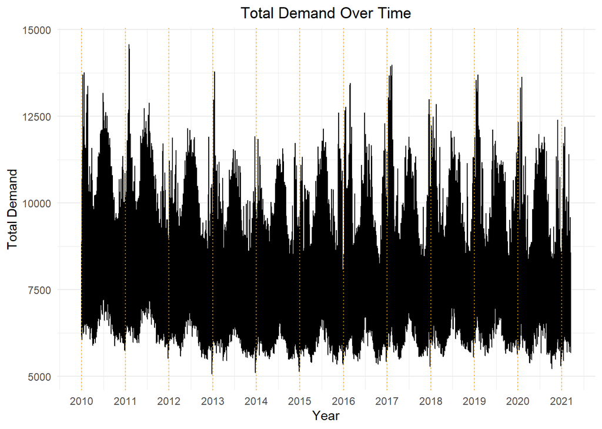

Figure 3.1: Total Demand Over Time.

```r
#The time series plot shows the fluctuation of electricity demand in New South Wales over 11 years. A clear seasonal pattern is observed, with peaks during winter and summer months, reflecting higher heating and cooling needs.

# Calculate sequence of years
year_sequence <- seq(from = floor_date(min(df_demand_nsw$DATETIME), "year"),
                     to = ceiling_date(max(df_demand_nsw$DATETIME), "year"),
                     by = "1 year")

# Plot data with vertical lines
df_demand_nsw %>%
  ggplot(aes(x = DATETIME, y = TOTALDEMAND)) +
  geom_line() +
  geom_vline(data = data.frame(x = year_sequence),
             aes(xintercept = as.numeric(x)),
             linetype = "dotted", color = "orange") +
  scale_x_datetime(date_breaks = '1 year', date_labels = '%Y') +
  labs(x = "Year", y = "Total Demand", title = "Total Demand Over Time") +
  theme_minimal() +
  theme(plot.title = element_text(hjust = 0.5))
```

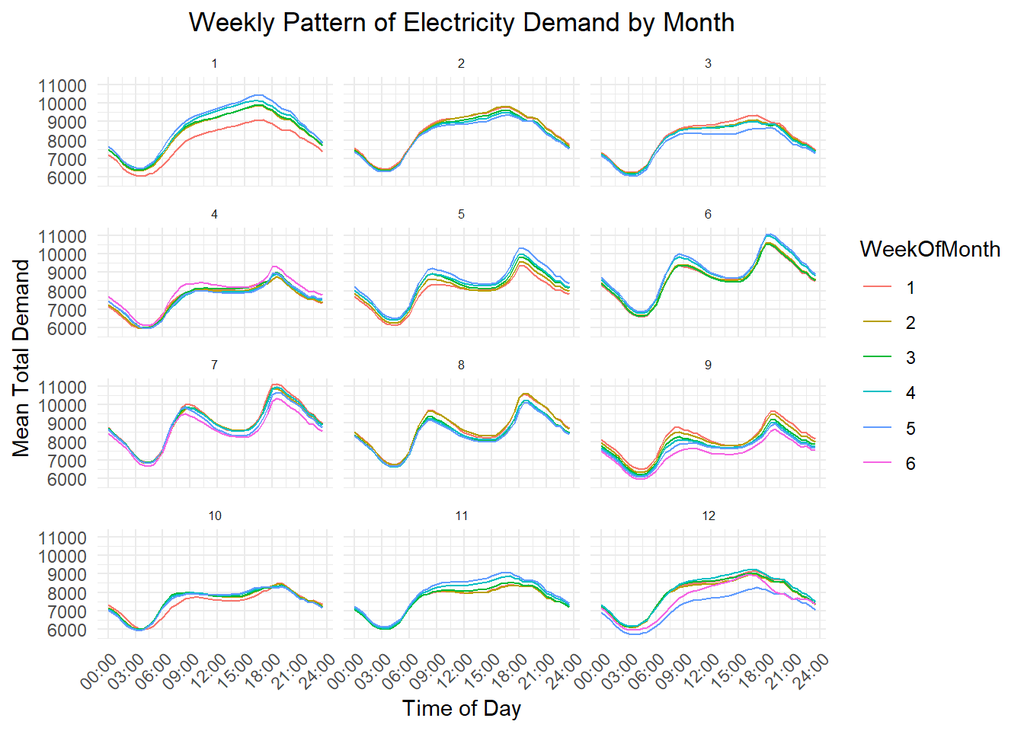

```r
#This set of line graphs illustrates the average electricity demand throughout a typical week in each month of the year, with lines representing different weeks within each month.
df_demand_nsw_monthly <- df_demand_nsw %>%
  group_by(Month, WeekOfMonth, TimeOfDay) %>%
  summarise(MeanDemand = mean(TOTALDEMAND)) %>%
  ungroup()

df_demand_nsw_monthly %>%
  ggplot(aes(x = TimeOfDay, y = MeanDemand)) +
  geom_line(aes(color = WeekOfMonth)) +
  facet_wrap(~ Month, ncol = 3) +
  scale_x_continuous(name = "Time of Day", breaks = seq(0, 24, by = 3), labels = function(x) sprintf("%02d:00", x)) +
  scale_y_continuous(name = "Mean Total Demand") +
  labs(title = "Weekly Pattern of Electricity Demand by Month") +
  theme_minimal() +
  theme(axis.text.x = element_text(angle = 45, hjust = 1),
        strip.text.x = element_text(size = 6), legend.position = "right", plot.title = element_text(hjust = 0.5))
```

There is a consistent daily pattern across all months, with demand increasing during the day and peaking in the early evening before dropping off at night. This likely reflects increased household and business activity during daylight hours and reduced activity overnight.

There are some differences in the daily patterns across the months, which seem to be influenced by seasonal changes.

Within each month, the weekly patterns remain relatively consistent, although there are slight variations in demand from week to week. This consistency indicates a stable electricity usage pattern within a month across different weeks.

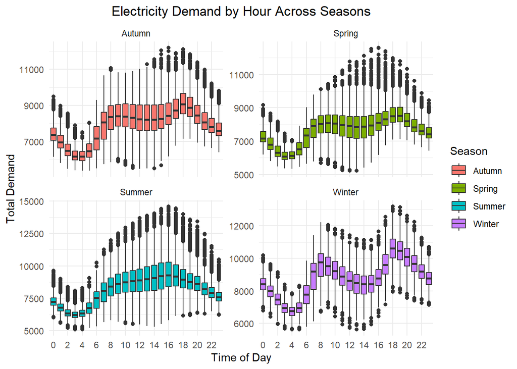

Figure 3.2: Demand by Hour Across Seasons.

```r
# This plot prints the seasonal demand of electricity for entire data
# Create a new column 'Season' based on the month
df_demand_nsw_seasonly <- df_demand_nsw %>%
  mutate(Season = case_when(
    Month %in% c(12, 1, 2) ~ "Summer",
    Month %in% c(3, 4, 5) ~ "Autumn",
    Month %in% c(6, 7, 8) ~ "Winter",
    Month %in% c(9, 10, 11) ~ "Spring",
    TRUE ~ NA_character_))

# Plot boxplots
df_demand_nsw_seasonly %>%
  ggplot(aes(x = factor(Hour), y = TOTALDEMAND)) +  # Specify x and y variables
  geom_boxplot(aes(fill=Season)) +  # Add boxplots, fill by season
  facet_wrap(~Season, scales = "free_y") +  # Facet by season, with independent y-axes
  labs(title = "Electricity Demand by Hour Across Seasons",  # Set plot title and axis labels
       x = "Hour of Day",
       y = "Total Demand") +
  scale_x_discrete(name = "Time of Day", breaks = seq(0, 24, by = 2)) +  # Customize x-axis
  theme_minimal() +  # Apply minimal theme
  theme(axis.text.x = element_text(angle = 0, hjust = 0.5),  # Improve readability of x-axis labels
        plot.title = element_text(hjust = 0.5))  # Center plot title
```

Autumn (Red) and Spring (Green): These seasons exhibit relatively consistent electricity demand with slight increases in the evening hours, likely reflective of the typical residential consumption patterns during these milder months.

Summer (Cyan): The demand profile during Summer shows a peak in midday to afternoon demand, establishing the anticipated increase in electricity use for cooling as the day reaches its highest temperatures.

Winter (Purple): Winter shows distinct peaks in demand in the early morning and evening, likely due to heating requirements during the colder parts of the day, which aligns with our initial observations of potential seasonal impacts on electricity use.

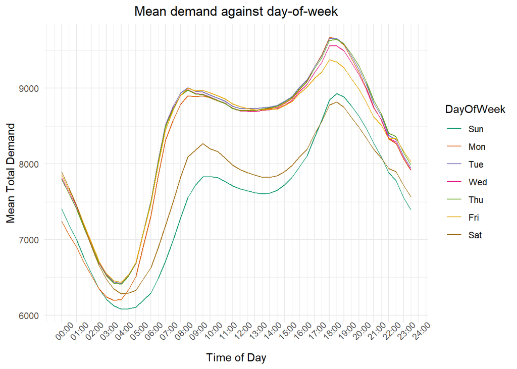

Figure 3.3: Mean Demand by Hour of Each Day of Week.

```r
# This code snippet segments the demand data by day of the week and time of day and calculates the mean demand for each combination. Then, it creates a line plot to visualize the mean total demand by time of day, with each line representing a different day of the week.

df_demand_nsw_weekly <- df_demand_nsw %>%
  group_by(DayOfWeek, TimeOfDay) %>%
  summarise(MeanDemand = mean(TOTALDEMAND, na.rm = TRUE))

df_demand_nsw_weekly %>% ggplot(aes(x = TimeOfDay, y = MeanDemand)) +
  geom_line(aes(color = DayOfWeek)) +
  scale_x_continuous(name = "Time of Day", breaks = seq(0, 24, by = 1), labels = function(x) sprintf("%02d:00", x)) +
  scale_y_continuous(name = "Mean Total Demand") +
  scale_color_brewer(palette = "Dark2") +
  labs(title = "Mean demand against day-of-week") +
  theme_minimal() +
  theme(axis.text.x = element_text(angle = 45, hjust = 0.5), plot.title = element_text(hjust = 0.5))
```

Weekday Demand (Monday to Friday): There is a pronounced double-peaked pattern on weekdays, with electricity demand rising sharply in the morning, tapering slightly midday, and then peaking again in the early evening. This likely reflects routine domestic and commercial activities, such as people getting ready for work and school in the morning and then returning home and using various appliances in the evening. Weekend Demand (Saturday and Sunday): The weekend pattern, while still showing two peaks similar to the weekdays, has less overall demand. Overall Trends: Across all days, there is a significant drop in demand late at night, when most residential and commercial activities cease, until early morning when the demand begins to rise with the start of a new day.

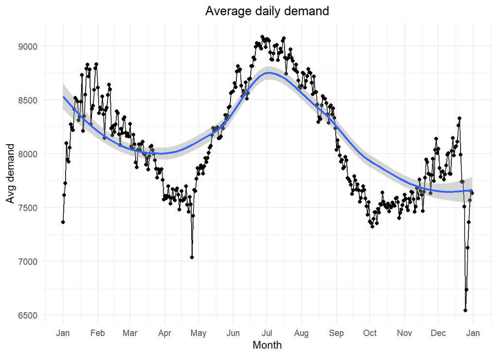

Figure 3.4: Average Daily Demand.

````r
# This code snippet calculates the average daily demand by grouping the data by month and day. It then creates a line plot to visualize the trend of average daily demand over time, with smoothed lines representing the trend.```

df_demand_nsw_daily <- df_demand_nsw %>%
  group_by(Month, Day) %>%
  summarise(Avg_daily_demand = mean(TOTALDEMAND)) %>%
  mutate(DATE = make_date(year=2012, month=Month, day=Day),
         MonthName = month(DATE, label=TRUE))

df_demand_nsw_daily %>%
  ggplot(aes(x = DATE, y = Avg_daily_demand)) +
  geom_line() + # Draw lines between points
  geom_point() + # Add points for each data point
  geom_smooth() +
  scale_x_date(date_breaks = "1 month", date_labels = "%b") + # Customize x-axis labels
  labs(x = "Month", y = "Avg demand", title = "Average daily demand") +
  theme_minimal() + # Use a minimal theme
  theme(plot.title = element_text(hjust = 0.5)
)
````

We see some extremes lows, seems to be the effect of holidays, will dive into that later.

## 3.2 Temperature

```r
summary(data_temperature_nsw)
```

```
##    LOCATION           DATETIME          TEMPERATURE
##  Length:220326      Length:220326      Min.   :-1.30
##  Class :character   Class :character   1st Qu.:13.40
##  Mode  :character   Mode  :character   Median :17.70
##                                        Mean   :17.42
##                                        3rd Qu.:21.30
##                                        Max.   :44.70
```

```r
df_temperature_nsw <- wrangle_demand_data(data_temperature_nsw)
head(df_temperature_nsw)
```

```
## # A tibble: 6 × 11
##   LOCATION  DATETIME            TEMPERATURE  Year Month   Day  Hour Minute
##   <chr>     <dttm>                    <dbl> <dbl> <dbl> <int> <int>  <int>
## 1 Bankstown 2010-01-01 00:00:00        23.1  2010     1     1     0      0
## 2 Bankstown 2010-01-01 00:01:00        23.1  2010     1     1     0      1
## 3 Bankstown 2010-01-01 00:30:00        22.9  2010     1     1     0     30
## 4 Bankstown 2010-01-01 00:50:00        22.7  2010     1     1     0     50
## 5 Bankstown 2010-01-01 01:00:00        22.6  2010     1     1     1      0
## 6 Bankstown 2010-01-01 01:30:00        22.5  2010     1     1     1     30
## # ℹ 3 more variables: TimeOfDay <dbl>, WeekOfMonth <fct>, DayOfWeek <ord>
```

```r
df_temperature_nsw <- df_temperature_nsw %>%
  mutate(out_of_line = !(((Minute >= 45) | (Minute <= 14)) | ((Minute >= 15) & (Minute <= 44))))

# Count how many intervals are out of the expected line
sum_out_of_line <- sum(df_temperature_nsw$out_of_line, na.rm = TRUE)

# Print the count of out-of-line intervals
print(sum_out_of_line)
```

```
## [1] 0
```

```r
df_aligned_temperature_nsw <- df_temperature_nsw %>%
  # Create a new column for the aligned timestamp
  mutate(DATETIME = DATETIME %>%
           # Round down or up to the nearest 30-minute mark
           floor_date(unit = "30 minutes") %>%
           # Adjust the rounding (55-05 -> 0, 25-35 -> 30)
           {if_else(minute(.) >= 45 | minute(.) <= 14, . - minutes(minute(.)), .)} %>%
           {if_else(minute(.) >= 15 & minute(.) <= 44, . + minutes(30 - minute(.)), .)}) %>%
  # Group by this new column
  group_by(DATETIME) %>%
  # Calculate the mean temperature for each group
  summarise(TEMPERATURE = mean(TEMPERATURE))
```

```r
head(df_aligned_temperature_nsw)
```

```
## # A tibble: 6 × 2
##   DATETIME            TEMPERATURE
##   <dttm>                    <dbl>
## 1 2010-01-01 00:00:00        23.1
## 2 2010-01-01 00:30:00        22.8
## 3 2010-01-01 01:00:00        22.6
## 4 2010-01-01 01:30:00        22.5
## 5 2010-01-01 02:00:00        22.5
## 6 2010-01-01 02:30:00        22.4
```

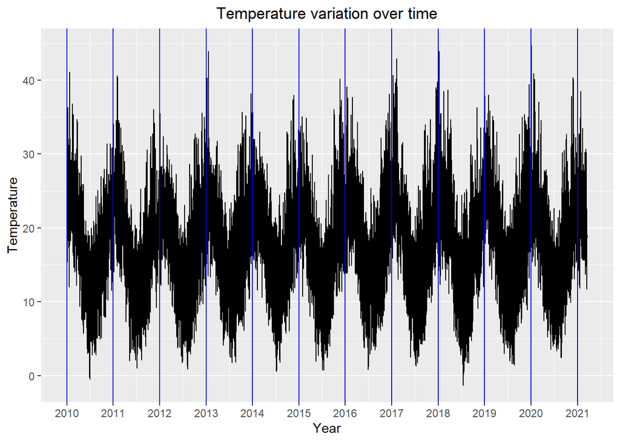

Figure 3.5: Temperature Over Time.

```r
#This code produces a plot with temperature data over time, blue vertical lines indicating the start of each year.

df_aligned_temperature_nsw %>%
  ggplot(aes(x = DATETIME, y = TEMPERATURE)) +
  geom_line() +
  geom_vline(data = data.frame(x = seq(from = floor_date(min(df_temperature_nsw$DATETIME), "year"),
                                       to = ceiling_date(max(df_temperature_nsw$DATETIME), "year"),
                                       by = "1 year")),
             aes(xintercept = as.numeric(x)),
              color = "blue") +  # Change the color to red
  scale_x_datetime(date_breaks = "1 year", date_labels = "%Y") +
  labs(x = "Year", y = "Temperature", title = "Temperature variation over time") +
  theme(plot.title = element_text(hjust = 0.5)
)
```

The data shows strong seasonality in the variation.

## 3.3 Forecast Data

The lastest LASTCHANGED forecastdemand for each DATETIME is selected.

```r
head(data_forecastdemand_nsw)
```

```
## # A tibble: 6 × 6
##   PREDISPATCHSEQNO REGIONID PERIODID FORECASTDEMAND LASTCHANGED
##              <dbl> <chr>       <dbl>          <dbl> <dttm>
## 1       2009123018 NSW1           71          7832. 2009-12-30 12:31:49
## 2       2009123019 NSW1           70          7832. 2009-12-30 13:01:43
## 3       2009123020 NSW1           69          7832. 2009-12-30 13:31:36
## 4       2009123021 NSW1           68          7832. 2009-12-30 14:01:44
## 5       2009123022 NSW1           67          7831. 2009-12-30 14:31:35
## 6       2009123023 NSW1           66          7842. 2009-12-30 15:01:42
## # ℹ 1 more variable: DATETIME <dttm>
```

```r
df_forecastdemand_nsw <- data_forecastdemand_nsw %>%
  group_by(DATETIME) %>%
  filter(LASTCHANGED == max(LASTCHANGED))
```

# 4 Bivariate Analysis

## 4.1 Holiday vs non-Holidays impact on Demand

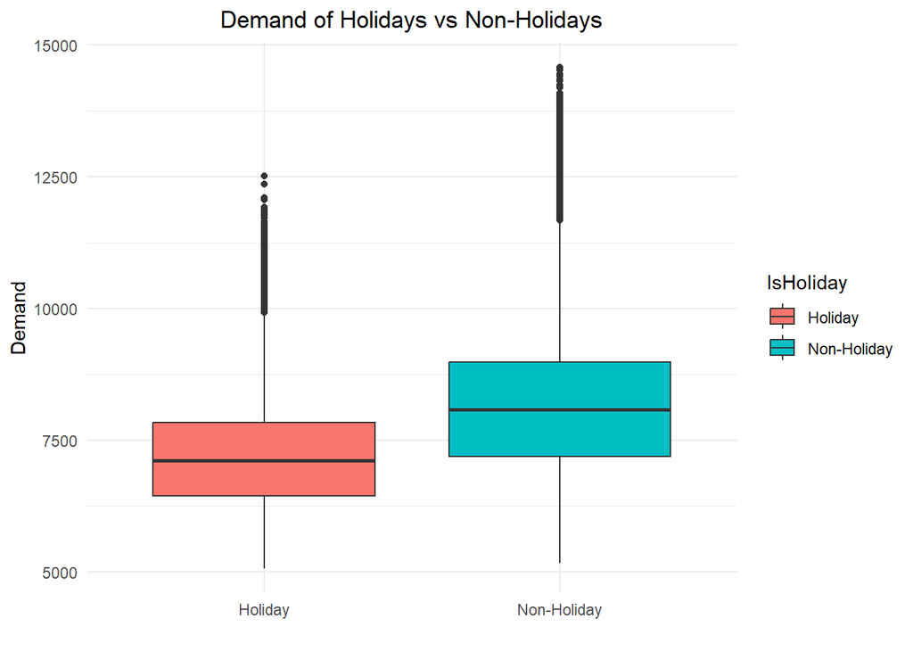

Figure 4.1: Effect of Holidays on Demand.

```r
df_demand_nsw <- df_demand_nsw %>%
  mutate(Date = date(DATETIME)) %>%
  mutate(
    IsHoliday = case_when(
      date(DATETIME) %in% holidays_nsw$Date ~ 'Holiday',
      TRUE ~ 'Non-Holiday'
    ))

# Boxplot to compare electricity demand on holidays vs non-holidays
df_demand_nsw %>%
  ggplot(aes(x = IsHoliday, y = TOTALDEMAND)) +
  geom_boxplot(aes(fill=IsHoliday)) +
  labs(title = "Demand of Holidays vs Non-Holidays",
       x = "", y = "Demand") +
  theme_minimal() +
  theme(plot.title = element_text(hjust = 0.5))
```

The box plot compares electricity demand on holidays versus non-holidays. It appears that the median electricity demand on holidays is lower than on non-holidays. There are several extreme values that deviate from the typical ranges on both types of days.

## 4.2 Demand vs Temperature

```r
# Inner join to get only matched data
df_nsw <- inner_join(df_demand_nsw, df_aligned_temperature_nsw, by = "DATETIME")

# Outer join to find unmatched data
unmatched_demand <- anti_join(df_demand_nsw, df_aligned_temperature_nsw, by = "DATETIME")
unmatched_temperature <- anti_join(df_aligned_temperature_nsw, df_demand_nsw, by = "DATETIME")

# Combine the unmatched data into one tibble
excluded_data <- bind_rows(unmatched_demand, unmatched_temperature)

# Optionally, add a column to indicate the source of each row in the excluded data
excluded_data <- excluded_data %>%
  mutate(Source = ifelse(is.na(TEMPERATURE), "Demand Only", "Temperature Only"))

nrow(excluded_data)
```

```
## [1] 559
```

```r
unique(excluded_data$Source)
```

```
## [1] "Demand Only"
```

Correlation testing

```r
cor.test(df_nsw$TEMPERATURE, df_nsw$TOTALDEMAND, use = "pearson")
```

```
##
##  Pearson's product-moment correlation
##
## data:  df_nsw$TEMPERATURE and df_nsw$TOTALDEMAND
## t = 66.701, df = 195952, p-value < 2.2e-16
## alternative hypothesis: true correlation is not equal to 0
## 95 percent confidence interval:
##  0.1446675 0.1533262
## sample estimates:
##       cor
## 0.1489997
```

Pearson correlation test: p-value is small reject null-hypothesis, it is statistically significant to say the true correlation of demand and temperature is not equal to 0.

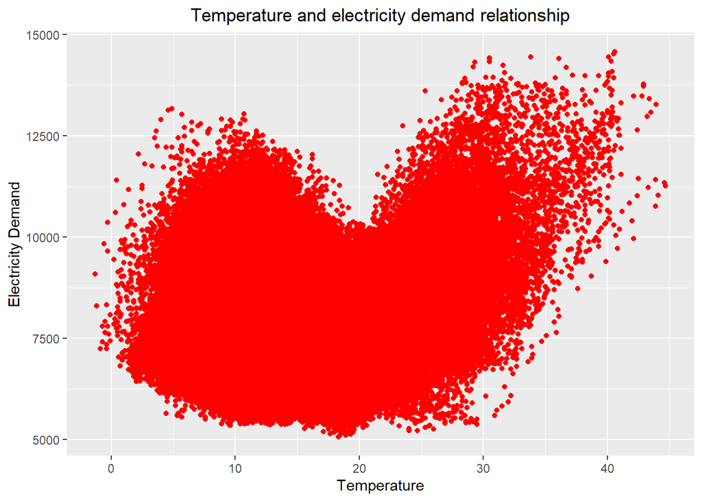

Figure 4.2: Relationship between Demand and Temperature.

```r
df_nsw %>%
  ggplot(aes(x = TEMPERATURE, y = TOTALDEMAND, color = "Data Points")) +  # Set color aesthetic
  geom_point(color = "red") +
  labs(title = "Temperature and electricity demand relationship",
       x = "Temperature",
       y = "Electricity Demand") +
theme(plot.title = element_text(hjust = 0.5))
```

## 4.3 Converts to Daily Data

```r
df_solar_expo_nsw <- solar_expo_nsw %>%
  mutate(Solar_exposure = `Daily global solar exposure (MJ/m*m)`,
         DATE = make_date(year = Year, month = Month, day = Day)) %>%
  filter(Year >= 2010 & Year <= 2022) %>%
  select(DATE, Solar_exposure)

df_solar_expo_nsw <- df_solar_expo_nsw %>%
  filter(!is.na(Solar_exposure))

df_rainfall_nsw <- rainfall_nsw %>%
  mutate(Rainfall_amount = `Rainfall amount (millimetres)`,
         DATE = make_date(year = Year, month = Month, day = Day)) %>%
  filter(Year >= 2010 & Year <= 2022) %>%
  select(DATE, Rainfall_amount)

median_rainfall <- median(df_rainfall_nsw$Rainfall_amount, na.rm = TRUE)
# Impute NA values in Rainfall_amount with the median

df_rainfall_nsw <- df_rainfall_nsw %>%
  mutate(Rainfall_amount = ifelse(is.na(Rainfall_amount), median_rainfall, Rainfall_amount))
```

```r
# Converts to daily data to match solar exposure and rainfall
df_nsw_daily <- df_nsw %>%
  mutate(DATE = as.Date(DATETIME)) %>%
  group_by(DATE) %>%
  summarise(Daily_Mean_Temperature = mean(TEMPERATURE, na.rm = TRUE),
            Daily_Max_Temperature = max(TEMPERATURE, na.rm = TRUE),
            Daily_Min_Temperature = min(TEMPERATURE, na.rm = TRUE),
            Daily_Mean_Demand = mean(TOTALDEMAND, na.rm = TRUE),
            Daily_Max_Demand = max(TOTALDEMAND, na.rm = TRUE),
            Daily_Min_Demand = min(TOTALDEMAND, na.rm = TRUE)) %>%
    ungroup() %>%
    mutate(WeekOfMonth = factor(week(DATE) - week(floor_date(DATE, "month")) + 1, levels = c(1,2,3,4,5,6)),
           DayOfWeek = factor(wday(DATE, label=TRUE), levels = c("Sun", "Mon", "Tue", "Wed", "Thu", "Fri", "Sat")))

df_nsw_daily <- inner_join(df_nsw_daily, df_solar_expo_nsw, by = 'DATE')
```

```r
# Transform the data from wide to long format
df_nsw_daily_long <- df_nsw_daily %>%
  pivot_longer(cols = c("Daily_Mean_Demand", "Daily_Max_Demand", "Daily_Min_Demand"),
               names_to = "Demand_Type",
               values_to = "Demand") %>%
    pivot_longer(cols = c("Daily_Mean_Temperature", "Daily_Max_Temperature", "Daily_Min_Temperature"),
               names_to = "Temperature_Type",
               values_to = "Temperature")
```

## 4.4 Solar Exposure vs Daily Demand

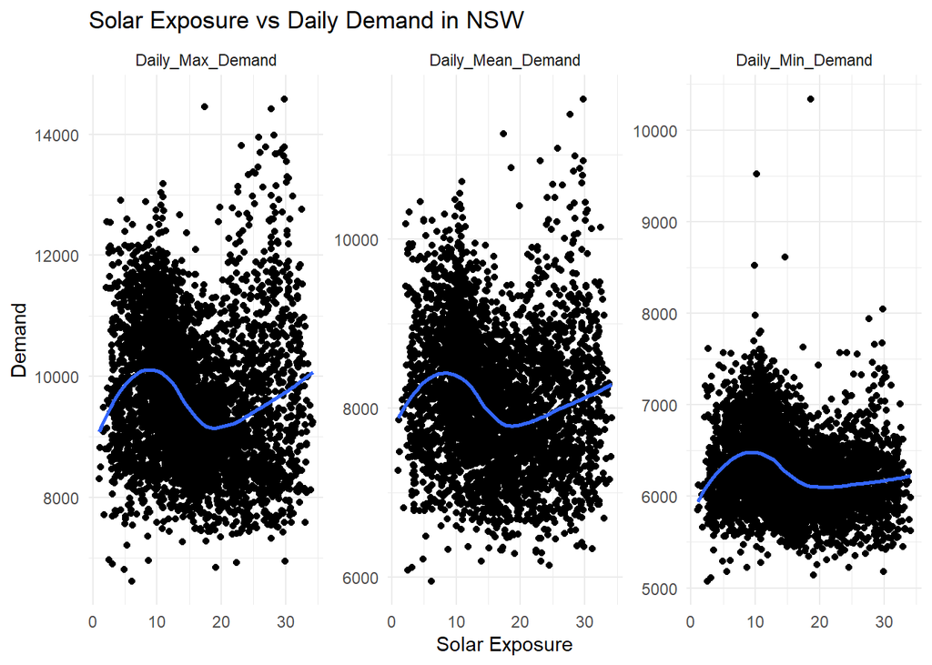

Figure 4.3: Relationship between Solar Exposure and Daily Demand.

```r
# Plotting with faceting
ggplot(df_nsw_daily_long, aes(x = Solar_exposure, y = Demand)) +
  geom_point() +
  geom_smooth(se = FALSE, method = "loess") +
  ggtitle("Solar Exposure vs Daily Demand in NSW") +
  xlab("Solar Exposure") +
  ylab("Demand") +
  facet_wrap(~Demand_Type, scales = "free_y") + # Create a separate panel for each Demand_Type
  theme_minimal()
```

## 4.5 Solar Exposure vs Daily Temperature

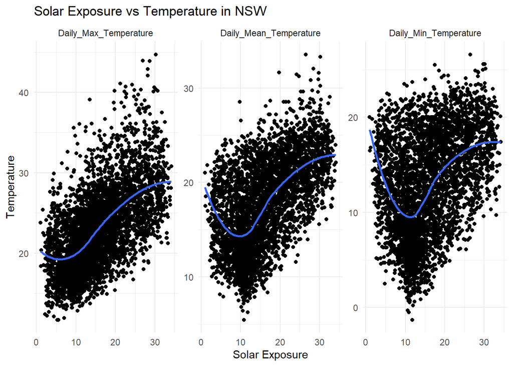

Figure 4.4: Relationship between Solar Exposure and Daily Temperature

```r
# Plotting with faceting
ggplot(df_nsw_daily_long, aes(x = Solar_exposure, y = Temperature)) +
  geom_point() +
  geom_smooth(se = FALSE, method = "loess") +
  ggtitle("Solar Exposure vs Temperature in NSW") +
  xlab("Solar Exposure") +
  ylab("Temperature") +
  facet_wrap(~Temperature_Type, scales = "free_y") +
  theme_minimal()
```

```r
cor.test(df_nsw_daily$Daily_Mean_Demand, df_nsw_daily$Solar_exposure, use="pearson")
```

```
##
##  Pearson's product-moment correlation
##
## data:  df_nsw_daily$Daily_Mean_Demand and df_nsw_daily$Solar_exposure
## t = -10.091, df = 4088, p-value < 2.2e-16
## alternative hypothesis: true correlation is not equal to 0
## 95 percent confidence interval:
##  -0.1856615 -0.1258529
## sample estimates:
##        cor
## -0.1559001
```

```r
cor.test(df_nsw_daily$Daily_Max_Demand, df_nsw_daily$Solar_exposure, use="pearson")
```

```
##
##  Pearson's product-moment correlation
##
## data:  df_nsw_daily$Daily_Max_Demand and df_nsw_daily$Solar_exposure
## t = -9.0269, df = 4088, p-value < 2.2e-16
## alternative hypothesis: true correlation is not equal to 0
## 95 percent confidence interval:
##  -0.1697186 -0.1096184
## sample estimates:
##        cor
## -0.1397972
```

```r
cor.test(df_nsw_daily$Daily_Min_Demand, df_nsw_daily$Solar_exposure, use="pearson")
```

```
##
##  Pearson's product-moment correlation
##
## data:  df_nsw_daily$Daily_Min_Demand and df_nsw_daily$Solar_exposure
## t = -14.905, df = 4088, p-value < 2.2e-16
## alternative hypothesis: true correlation is not equal to 0
## 95 percent confidence interval:
##  -0.2559000 -0.1977596
## sample estimates:
##        cor
## -0.2270321
```

```r
cor.test(df_nsw_daily$Daily_Mean_Temperature, df_nsw_daily$Solar_exposure, use="pearson")
```

```
##
##  Pearson's product-moment correlation
##
## data:  df_nsw_daily$Daily_Mean_Temperature and df_nsw_daily$Solar_exposure
## t = 42.753, df = 4088, p-value < 2.2e-16
## alternative hypothesis: true correlation is not equal to 0
## 95 percent confidence interval:
##  0.5343070 0.5766773
## sample estimates:
##       cor
## 0.5558531
```

```r
cor.test(df_nsw_daily$Daily_Max_Temperature, df_nsw_daily$Solar_exposure, use="pearson")
```

```
##
##  Pearson's product-moment correlation
##
## data:  df_nsw_daily$Daily_Max_Temperature and df_nsw_daily$Solar_exposure
## t = 49.338, df = 4088, p-value < 2.2e-16
## alternative hypothesis: true correlation is not equal to 0
## 95 percent confidence interval:
##  0.5913426 0.6297757
## sample estimates:
##      cor
## 0.610919
```

```r
cor.test(df_nsw_daily$Daily_Min_Temperature, df_nsw_daily$Solar_exposure, use="pearson")
```

```
##
##  Pearson's product-moment correlation
##
## data:  df_nsw_daily$Daily_Min_Temperature and df_nsw_daily$Solar_exposure
## t = 27.473, df = 4088, p-value < 2.2e-16
## alternative hypothesis: true correlation is not equal to 0
## 95 percent confidence interval:
##  0.3685963 0.4203475
## sample estimates:
##      cor
## 0.394785
```

## 4.6 Rainfall vs Daily Demand

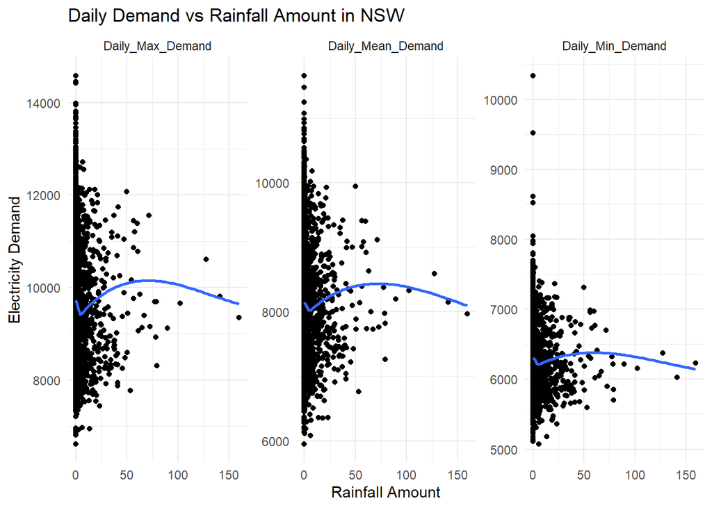

```r
df_nsw_daily <- inner_join(df_nsw_daily, df_rainfall_nsw)
df_nsw_daily_long <- inner_join(df_nsw_daily_long, df_rainfall_nsw)

# Plotting with faceting
ggplot(df_nsw_daily_long, aes(x = Rainfall_amount, y = Demand)) +
  geom_point() +
  geom_smooth(se = FALSE, method = "loess") +
  ggtitle("Daily Demand vs Rainfall Amount in NSW") +
  xlab("Rainfall Amount") +
  ylab("Electricity Demand") +
  facet_wrap(~Demand_Type, scales = "free_y") + # Create a separate panel for each Demand_Type
  theme_minimal()
```